# Risk Factor Analysis

## Outcome Variable

**Outcome Variable:** ever_stunted

## Predictor Variables

**Intervention Variable:** predfeed3

**Adjustment Set:**

- arm
- sex
- month
- brthmon
- W_mage
- meducyrs
- feducyrs
- hhwealth_quart
- hfoodsec
- W_mhtcm
- W_mwtkg
- W_mbmi
- vagbrth
- W_gagebrth
- W_birthwt
- W_birthlen
- W_nrooms
- W_nchldlt5
- W_parity
- impfloor
- impsan
- safeh20
- delta_W_mage
- delta_meducyrs
- delta_feducyrs
- delta_hhwealth_quart
- delta_hfoodsec
- delta_W_mhtcm
- delta_W_mwtkg
- delta_W_mbmi
- delta_vagbrth
- delta_W_gagebrth
- delta_W_birthwt
- delta_W_birthlen
- delta_W_nrooms
- delta_W_nchldlt5
- delta_W_parity
- delta_impfloor
- delta_impsan
- delta_safeh20

## Stratifying Variables

The analysis was stratified on these variable(s):

- agecat
- studyid
- country

## Data Summary

| agecat | studyid | country | predfeed3 | ever_stunted | n_cell | n |
| --- | --- | --- | --- | --- | --- | --- |
| 0-24 months (no birth st.) | EE | PAKISTAN | 1 | 0 | 4 | 21 |
| 0-24 months (no birth st.) | EE | PAKISTAN | 1 | 1 | 17 | 21 |
| 0-24 months (no birth st.) | EE | PAKISTAN | 0 | 0 | 0 | 21 |
| 0-24 months (no birth st.) | EE | PAKISTAN | 0 | 1 | 0 | 21 |
| 0-24 months (no birth st.) | GMS-Nepal | NEPAL | 1 | 0 | 116 | 380 |
| 0-24 months (no birth st.) | GMS-Nepal | NEPAL | 1 | 1 | 201 | 380 |
| 0-24 months (no birth st.) | GMS-Nepal | NEPAL | 0 | 0 | 22 | 380 |
| 0-24 months (no birth st.) | GMS-Nepal | NEPAL | 0 | 1 | 41 | 380 |
| 0-24 months (no birth st.) | JiVitA-3 | BANGLADESH | 1 | 0 | 6792 | 10148 |
| 0-24 months (no birth st.) | JiVitA-3 | BANGLADESH | 1 | 1 | 2425 | 10148 |
| 0-24 months (no birth st.) | JiVitA-3 | BANGLADESH | 0 | 0 | 689 | 10148 |
| 0-24 months (no birth st.) | JiVitA-3 | BANGLADESH | 0 | 1 | 242 | 10148 |
| 0-24 months (no birth st.) | JiVitA-4 | BANGLADESH | 1 | 0 | 63 | 113 |
| 0-24 months (no birth st.) | JiVitA-4 | BANGLADESH | 1 | 1 | 40 | 113 |
| 0-24 months (no birth st.) | JiVitA-4 | BANGLADESH | 0 | 0 | 4 | 113 |
| 0-24 months (no birth st.) | JiVitA-4 | BANGLADESH | 0 | 1 | 6 | 113 |
| 0-24 months (no birth st.) | MAL-ED | BANGLADESH | 1 | 0 | 78 | 202 |
| 0-24 months (no birth st.) | MAL-ED | BANGLADESH | 1 | 1 | 86 | 202 |
| 0-24 months (no birth st.) | MAL-ED | BANGLADESH | 0 | 0 | 16 | 202 |
| 0-24 months (no birth st.) | MAL-ED | BANGLADESH | 0 | 1 | 22 | 202 |
| 0-24 months (no birth st.) | MAL-ED | BRAZIL | 1 | 0 | 69 | 175 |
| 0-24 months (no birth st.) | MAL-ED | BRAZIL | 1 | 1 | 17 | 175 |
| 0-24 months (no birth st.) | MAL-ED | BRAZIL | 0 | 0 | 75 | 175 |
| 0-24 months (no birth st.) | MAL-ED | BRAZIL | 0 | 1 | 14 | 175 |
| 0-24 months (no birth st.) | MAL-ED | INDIA | 1 | 0 | 48 | 184 |
| 0-24 months (no birth st.) | MAL-ED | INDIA | 1 | 1 | 79 | 184 |
| 0-24 months (no birth st.) | MAL-ED | INDIA | 0 | 0 | 35 | 184 |
| 0-24 months (no birth st.) | MAL-ED | INDIA | 0 | 1 | 22 | 184 |
| 0-24 months (no birth st.) | MAL-ED | NEPAL | 1 | 0 | 77 | 201 |
| 0-24 months (no birth st.) | MAL-ED | NEPAL | 1 | 1 | 28 | 201 |

[output cut: 58 more lines]

The following strata were considered:

- agecat: 0-24 months (no birth st.), studyid: EE, country: PAKISTAN
- agecat: 0-24 months (no birth st.), studyid: GMS-Nepal, country: NEPAL
- agecat: 0-24 months (no birth st.), studyid: JiVitA-3, country: BANGLADESH
- agecat: 0-24 months (no birth st.), studyid: JiVitA-4, country: BANGLADESH
- agecat: 0-24 months (no birth st.), studyid: MAL-ED, country: BANGLADESH
- agecat: 0-24 months (no birth st.), studyid: MAL-ED, country: BRAZIL
- agecat: 0-24 months (no birth st.), studyid: MAL-ED, country: INDIA
- agecat: 0-24 months (no birth st.), studyid: MAL-ED, country: NEPAL
- agecat: 0-24 months (no birth st.), studyid: MAL-ED, country: PERU
- agecat: 0-24 months (no birth st.), studyid: MAL-ED, country: SOUTH AFRICA
- agecat: 0-24 months (no birth st.), studyid: MAL-ED, country: TANZANIA, UNITED REPUBLIC OF
- agecat: 0-6 months (no birth st.), studyid: EE, country: PAKISTAN
- agecat: 0-6 months (no birth st.), studyid: GMS-Nepal, country: NEPAL
- agecat: 0-6 months (no birth st.), studyid: JiVitA-3, country: BANGLADESH
- agecat: 0-6 months (no birth st.), studyid: JiVitA-4, country: BANGLADESH
- agecat: 0-6 months (no birth st.), studyid: MAL-ED, country: BANGLADESH
- agecat: 0-6 months (no birth st.), studyid: MAL-ED, country: BRAZIL
- agecat: 0-6 months (no birth st.), studyid: MAL-ED, country: INDIA
- agecat: 0-6 months (no birth st.), studyid: MAL-ED, country: NEPAL
- agecat: 0-6 months (no birth st.), studyid: MAL-ED, country: PERU
- agecat: 0-6 months (no birth st.), studyid: MAL-ED, country: SOUTH AFRICA
- agecat: 0-6 months (no birth st.), studyid: MAL-ED, country: TANZANIA, UNITED REPUBLIC OF

### Dropped Strata

Some strata were dropped due to rare outcomes:

- agecat: 0-24 months (no birth st.), studyid: EE, country: PAKISTAN
- agecat: 0-24 months (no birth st.), studyid: JiVitA-4, country: BANGLADESH
- agecat: 0-6 months (no birth st.), studyid: EE, country: PAKISTAN
- agecat: 0-6 months (no birth st.), studyid: JiVitA-4, country: BANGLADESH
- agecat: 0-6 months (no birth st.), studyid: MAL-ED, country: NEPAL

## Methods Detail

We're interested in the causal parameters $E[Y_a]$ for all values of $a \in \mathcal{A}$. These parameters represent the mean outcome if, possibly contrary to fact, we intervened to set all units to have $A=a$. Under the randomization and positivity assumptions, these are identified by the statistical parameters $\psi_a=E_W[E_{Y|A,W}(Y|A=a,W)]$. In addition, we're interested in the mean of $Y$, $E[Y]$ under no intervention (the observed mean). We will estimate these parameters by using SuperLearner to fit the relevant likelihood factors -- $E_{Y|A,W}(Y|A=a,W)$ and $p(A=a|W)$, and then updating our likelihood fit using a joint TMLE.

For unadjusted analyses ($W=\{\}$), initial likelihoods were estimated using Lrnr_glm to estimate the simple $E(Y|A)$ and Lrnr_mean to estimate $p(A)$. For adjusted analyses, a small library containing Lrnr_glmnet, Lrnr_xgboost, and Lrnr_mean was used.

Having estimated these parameters, we will then use the delta method to estimate relative risks and attributable risks relative to a prespecified baseline level of $A$.

# Results Detail

## Results Plots

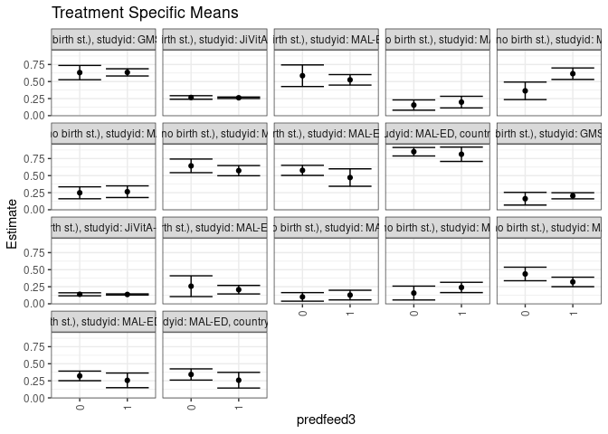

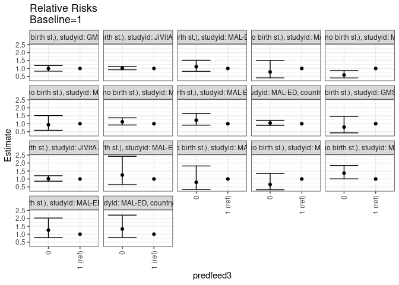

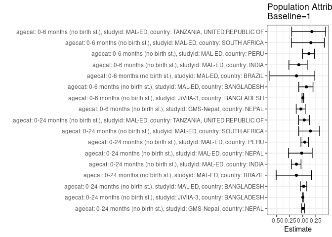

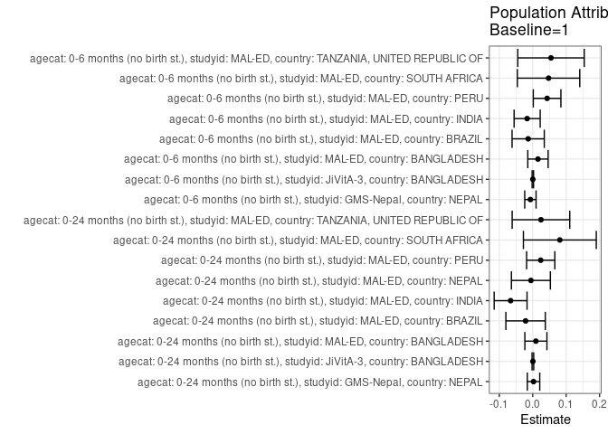

## Results Table

### Parameter: TSM

| agecat | studyid | country | intervention_level | baseline_level | estimate | ci_lower | ci_upper |
| --- | --- | --- | --- | --- | --- | --- | --- |
| 0-24 months (no birth st.) | GMS-Nepal | NEPAL | 1 | NA | 0.6344581 | 0.5817957 | 0.6871205 |
| 0-24 months (no birth st.) | GMS-Nepal | NEPAL | 0 | NA | 0.6313928 | 0.5265836 | 0.7362020 |
| 0-24 months (no birth st.) | JiVitA-3 | BANGLADESH | 1 | NA | 0.2623346 | 0.2515592 | 0.2731100 |
| 0-24 months (no birth st.) | JiVitA-3 | BANGLADESH | 0 | NA | 0.2668876 | 0.2409188 | 0.2928564 |
| 0-24 months (no birth st.) | MAL-ED | BANGLADESH | 1 | NA | 0.5251695 | 0.4483890 | 0.6019500 |
| 0-24 months (no birth st.) | MAL-ED | BANGLADESH | 0 | NA | 0.5854117 | 0.4270974 | 0.7437260 |
| 0-24 months (no birth st.) | MAL-ED | BRAZIL | 1 | NA | 0.1984809 | 0.1133063 | 0.2836555 |
| 0-24 months (no birth st.) | MAL-ED | BRAZIL | 0 | NA | 0.1553940 | 0.0802096 | 0.2305785 |
| 0-24 months (no birth st.) | MAL-ED | INDIA | 1 | NA | 0.6150907 | 0.5308102 | 0.6993711 |
| 0-24 months (no birth st.) | MAL-ED | INDIA | 0 | NA | 0.3637240 | 0.2349634 | 0.4924846 |
| 0-24 months (no birth st.) | MAL-ED | NEPAL | 1 | NA | 0.2641715 | 0.1786803 | 0.3496627 |
| 0-24 months (no birth st.) | MAL-ED | NEPAL | 0 | NA | 0.2481589 | 0.1608541 | 0.3354636 |
| 0-24 months (no birth st.) | MAL-ED | PERU | 1 | NA | 0.5729502 | 0.4982475 | 0.6476528 |
| 0-24 months (no birth st.) | MAL-ED | PERU | 0 | NA | 0.6432285 | 0.5435803 | 0.7428767 |
| 0-24 months (no birth st.) | MAL-ED | SOUTH AFRICA | 1 | NA | 0.4716287 | 0.3440102 | 0.5992471 |
| 0-24 months (no birth st.) | MAL-ED | SOUTH AFRICA | 0 | NA | 0.5772054 | 0.5031947 | 0.6512162 |
| 0-24 months (no birth st.) | MAL-ED | TANZANIA, UNITED REPUBLIC OF | 1 | NA | 0.8132160 | 0.7079982 | 0.9184338 |
| 0-24 months (no birth st.) | MAL-ED | TANZANIA, UNITED REPUBLIC OF | 0 | NA | 0.8504871 | 0.7880713 | 0.9129028 |
| 0-6 months (no birth st.) | GMS-Nepal | NEPAL | 1 | NA | 0.2043300 | 0.1598802 | 0.2487798 |
| 0-6 months (no birth st.) | GMS-Nepal | NEPAL | 0 | NA | 0.1612507 | 0.0684208 | 0.2540806 |
| 0-6 months (no birth st.) | JiVitA-3 | BANGLADESH | 1 | NA | 0.1369749 | 0.1290360 | 0.1449139 |
| 0-6 months (no birth st.) | JiVitA-3 | BANGLADESH | 0 | NA | 0.1392943 | 0.1171012 | 0.1614873 |
| 0-6 months (no birth st.) | MAL-ED | BANGLADESH | 1 | NA | 0.2071410 | 0.1446894 | 0.2695927 |
| 0-6 months (no birth st.) | MAL-ED | BANGLADESH | 0 | NA | 0.2578892 | 0.1055913 | 0.4101871 |
| 0-6 months (no birth st.) | MAL-ED | BRAZIL | 1 | NA | 0.1279070 | 0.0571170 | 0.1986970 |
| 0-6 months (no birth st.) | MAL-ED | BRAZIL | 0 | NA | 0.1011236 | 0.0383071 | 0.1639401 |
| 0-6 months (no birth st.) | MAL-ED | INDIA | 1 | NA | 0.2395303 | 0.1641883 | 0.3148724 |
| 0-6 months (no birth st.) | MAL-ED | INDIA | 0 | NA | 0.1575799 | 0.0561051 | 0.2590548 |
| 0-6 months (no birth st.) | MAL-ED | PERU | 1 | NA | 0.3206422 | 0.2509813 | 0.3903031 |
| 0-6 months (no birth st.) | MAL-ED | PERU | 0 | NA | 0.4373456 | 0.3377688 | 0.5369224 |
| 0-6 months (no birth st.) | MAL-ED | SOUTH AFRICA | 1 | NA | 0.2564164 | 0.1488086 | 0.3640243 |
| 0-6 months (no birth st.) | MAL-ED | SOUTH AFRICA | 0 | NA | 0.3217523 | 0.2513740 | 0.3921306 |
| 0-6 months (no birth st.) | MAL-ED | TANZANIA, UNITED REPUBLIC OF | 1 | NA | 0.2588405 | 0.1437783 | 0.3739028 |
| 0-6 months (no birth st.) | MAL-ED | TANZANIA, UNITED REPUBLIC OF | 0 | NA | 0.3429612 | 0.2607233 | 0.4251991 |

### Parameter: E(Y)

| agecat | studyid | country | intervention_level | baseline_level | estimate | ci_lower | ci_upper |
| --- | --- | --- | --- | --- | --- | --- | --- |
| 0-24 months (no birth st.) | GMS-Nepal | NEPAL | NA | NA | 0.6368421 | 0.5884257 | 0.6852585 |
| 0-24 months (no birth st.) | JiVitA-3 | BANGLADESH | NA | NA | 0.2628104 | 0.2524838 | 0.2731371 |
| 0-24 months (no birth st.) | MAL-ED | BANGLADESH | NA | NA | 0.5346535 | 0.4656971 | 0.6036099 |
| 0-24 months (no birth st.) | MAL-ED | BRAZIL | NA | NA | 0.1771429 | 0.1204149 | 0.2338709 |
| 0-24 months (no birth st.) | MAL-ED | INDIA | NA | NA | 0.5489130 | 0.4768182 | 0.6210079 |
| 0-24 months (no birth st.) | MAL-ED | NEPAL | NA | NA | 0.2587065 | 0.1980144 | 0.3193985 |
| 0-24 months (no birth st.) | MAL-ED | PERU | NA | NA | 0.5968379 | 0.5362738 | 0.6574021 |
| 0-24 months (no birth st.) | MAL-ED | SOUTH AFRICA | NA | NA | 0.5527426 | 0.4893071 | 0.6161781 |
| 0-24 months (no birth st.) | MAL-ED | TANZANIA, UNITED REPUBLIC OF | NA | NA | 0.8378378 | 0.7845787 | 0.8910970 |
| 0-6 months (no birth st.) | GMS-Nepal | NEPAL | NA | NA | 0.1973684 | 0.1572979 | 0.2374390 |
| 0-6 months (no birth st.) | JiVitA-3 | BANGLADESH | NA | NA | 0.1373090 | 0.1297510 | 0.1448670 |
| 0-6 months (no birth st.) | MAL-ED | BANGLADESH | NA | NA | 0.2227723 | 0.1652475 | 0.2802970 |
| 0-6 months (no birth st.) | MAL-ED | BRAZIL | NA | NA | 0.1142857 | 0.0670124 | 0.1615591 |
| 0-6 months (no birth st.) | MAL-ED | INDIA | NA | NA | 0.2228261 | 0.1625334 | 0.2831188 |
| 0-6 months (no birth st.) | MAL-ED | PERU | NA | NA | 0.3636364 | 0.3042435 | 0.4230292 |
| 0-6 months (no birth st.) | MAL-ED | SOUTH AFRICA | NA | NA | 0.3037975 | 0.2451226 | 0.3624723 |
| 0-6 months (no birth st.) | MAL-ED | TANZANIA, UNITED REPUBLIC OF | NA | NA | 0.3135135 | 0.2464813 | 0.3805457 |

### Parameter: RR

| agecat | studyid | country | intervention_level | baseline_level | estimate | ci_lower | ci_upper |
| --- | --- | --- | --- | --- | --- | --- | --- |
| 0-24 months (no birth st.) | GMS-Nepal | NEPAL | 1 | 1 | 1.0000000 | 1.0000000 | 1.000000 |
| 0-24 months (no birth st.) | GMS-Nepal | NEPAL | 0 | 1 | 0.9951687 | 0.8317369 | 1.190714 |
| 0-24 months (no birth st.) | JiVitA-3 | BANGLADESH | 1 | 1 | 1.0000000 | 1.0000000 | 1.000000 |
| 0-24 months (no birth st.) | JiVitA-3 | BANGLADESH | 0 | 1 | 1.0173557 | 0.9193409 | 1.125820 |
| 0-24 months (no birth st.) | MAL-ED | BANGLADESH | 1 | 1 | 1.0000000 | 1.0000000 | 1.000000 |
| 0-24 months (no birth st.) | MAL-ED | BANGLADESH | 0 | 1 | 1.1147100 | 0.8199930 | 1.515352 |
| 0-24 months (no birth st.) | MAL-ED | BRAZIL | 1 | 1 | 1.0000000 | 1.0000000 | 1.000000 |
| 0-24 months (no birth st.) | MAL-ED | BRAZIL | 0 | 1 | 0.7829167 | 0.4091631 | 1.498079 |
| 0-24 months (no birth st.) | MAL-ED | INDIA | 1 | 1 | 1.0000000 | 1.0000000 | 1.000000 |
| 0-24 months (no birth st.) | MAL-ED | INDIA | 0 | 1 | 0.5913339 | 0.4043149 | 0.864860 |
| 0-24 months (no birth st.) | MAL-ED | NEPAL | 1 | 1 | 1.0000000 | 1.0000000 | 1.000000 |
| 0-24 months (no birth st.) | MAL-ED | NEPAL | 0 | 1 | 0.9393856 | 0.5832075 | 1.513090 |
| 0-24 months (no birth st.) | MAL-ED | PERU | 1 | 1 | 1.0000000 | 1.0000000 | 1.000000 |
| 0-24 months (no birth st.) | MAL-ED | PERU | 0 | 1 | 1.1226605 | 0.9197698 | 1.370307 |
| 0-24 months (no birth st.) | MAL-ED | SOUTH AFRICA | 1 | 1 | 1.0000000 | 1.0000000 | 1.000000 |
| 0-24 months (no birth st.) | MAL-ED | SOUTH AFRICA | 0 | 1 | 1.2238556 | 0.9102038 | 1.645590 |
| 0-24 months (no birth st.) | MAL-ED | TANZANIA, UNITED REPUBLIC OF | 1 | 1 | 1.0000000 | 1.0000000 | 1.000000 |
| 0-24 months (no birth st.) | MAL-ED | TANZANIA, UNITED REPUBLIC OF | 0 | 1 | 1.0458317 | 0.9018162 | 1.212846 |
| 0-6 months (no birth st.) | GMS-Nepal | NEPAL | 1 | 1 | 1.0000000 | 1.0000000 | 1.000000 |
| 0-6 months (no birth st.) | GMS-Nepal | NEPAL | 0 | 1 | 0.7891680 | 0.4259899 | 1.461974 |
| 0-6 months (no birth st.) | JiVitA-3 | BANGLADESH | 1 | 1 | 1.0000000 | 1.0000000 | 1.000000 |
| 0-6 months (no birth st.) | JiVitA-3 | BANGLADESH | 0 | 1 | 1.0169326 | 0.8597057 | 1.202914 |
| 0-6 months (no birth st.) | MAL-ED | BANGLADESH | 1 | 1 | 1.0000000 | 1.0000000 | 1.000000 |
| 0-6 months (no birth st.) | MAL-ED | BANGLADESH | 0 | 1 | 1.2449934 | 0.6391006 | 2.425297 |
| 0-6 months (no birth st.) | MAL-ED | BRAZIL | 1 | 1 | 1.0000000 | 1.0000000 | 1.000000 |
| 0-6 months (no birth st.) | MAL-ED | BRAZIL | 0 | 1 | 0.7906027 | 0.3440626 | 1.816682 |
| 0-6 months (no birth st.) | MAL-ED | INDIA | 1 | 1 | 1.0000000 | 1.0000000 | 1.000000 |
| 0-6 months (no birth st.) | MAL-ED | INDIA | 0 | 1 | 0.6578705 | 0.3210735 | 1.347958 |
| 0-6 months (no birth st.) | MAL-ED | PERU | 1 | 1 | 1.0000000 | 1.0000000 | 1.000000 |
| 0-6 months (no birth st.) | MAL-ED | PERU | 0 | 1 | 1.3639676 | 1.0067181 | 1.847992 |
| 0-6 months (no birth st.) | MAL-ED | SOUTH AFRICA | 1 | 1 | 1.0000000 | 1.0000000 | 1.000000 |
| 0-6 months (no birth st.) | MAL-ED | SOUTH AFRICA | 0 | 1 | 1.2548037 | 0.7813934 | 2.015032 |
| 0-6 months (no birth st.) | MAL-ED | TANZANIA, UNITED REPUBLIC OF | 1 | 1 | 1.0000000 | 1.0000000 | 1.000000 |
| 0-6 months (no birth st.) | MAL-ED | TANZANIA, UNITED REPUBLIC OF | 0 | 1 | 1.3249903 | 0.7988183 | 2.197745 |

### Parameter: PAR

| agecat | studyid | country | intervention_level | baseline_level | estimate | ci_lower | ci_upper |
| --- | --- | --- | --- | --- | --- | --- | --- |
| 0-24 months (no birth st.) | GMS-Nepal | NEPAL | 1 | NA | 0.0023840 | -0.0162508 | 0.0210188 |
| 0-24 months (no birth st.) | JiVitA-3 | BANGLADESH | 1 | NA | 0.0004758 | -0.0019840 | 0.0029356 |
| 0-24 months (no birth st.) | MAL-ED | BANGLADESH | 1 | NA | 0.0094840 | -0.0235063 | 0.0424742 |
| 0-24 months (no birth st.) | MAL-ED | BRAZIL | 1 | NA | -0.0213381 | -0.0802871 | 0.0376110 |
| 0-24 months (no birth st.) | MAL-ED | INDIA | 1 | NA | -0.0661776 | -0.1153475 | -0.0170077 |
| 0-24 months (no birth st.) | MAL-ED | NEPAL | 1 | NA | -0.0054650 | -0.0637601 | 0.0528301 |
| 0-24 months (no birth st.) | MAL-ED | PERU | 1 | NA | 0.0238878 | -0.0182908 | 0.0660663 |
| 0-24 months (no birth st.) | MAL-ED | SOUTH AFRICA | 1 | NA | 0.0811139 | -0.0278753 | 0.1901031 |
| 0-24 months (no birth st.) | MAL-ED | TANZANIA, UNITED REPUBLIC OF | 1 | NA | 0.0246219 | -0.0614908 | 0.1107345 |
| 0-6 months (no birth st.) | GMS-Nepal | NEPAL | 1 | NA | -0.0069616 | -0.0239127 | 0.0099895 |
| 0-6 months (no birth st.) | JiVitA-3 | BANGLADESH | 1 | NA | 0.0003341 | -0.0017963 | 0.0024644 |
| 0-6 months (no birth st.) | MAL-ED | BANGLADESH | 1 | NA | 0.0156313 | -0.0147423 | 0.0460048 |
| 0-6 months (no birth st.) | MAL-ED | BRAZIL | 1 | NA | -0.0136213 | -0.0617946 | 0.0345521 |
| 0-6 months (no birth st.) | MAL-ED | INDIA | 1 | NA | -0.0167042 | -0.0557118 | 0.0223033 |
| 0-6 months (no birth st.) | MAL-ED | PERU | 1 | NA | 0.0429941 | 0.0016595 | 0.0843288 |
| 0-6 months (no birth st.) | MAL-ED | SOUTH AFRICA | 1 | NA | 0.0473810 | -0.0459441 | 0.1407062 |
| 0-6 months (no birth st.) | MAL-ED | TANZANIA, UNITED REPUBLIC OF | 1 | NA | 0.0546730 | -0.0446837 | 0.1540297 |

### Parameter: PAF

| agecat | studyid | country | intervention_level | baseline_level | estimate | ci_lower | ci_upper |
| --- | --- | --- | --- | --- | --- | --- | --- |
| 0-24 months (no birth st.) | GMS-Nepal | NEPAL | 1 | NA | 0.0037435 | -0.0259665 | 0.0325931 |
| 0-24 months (no birth st.) | JiVitA-3 | BANGLADESH | 1 | NA | 0.0018105 | -0.0075983 | 0.0111315 |
| 0-24 months (no birth st.) | MAL-ED | BANGLADESH | 1 | NA | 0.0177385 | -0.0460176 | 0.0776087 |
| 0-24 months (no birth st.) | MAL-ED | BRAZIL | 1 | NA | -0.1204568 | -0.5065772 | 0.1667049 |
| 0-24 months (no birth st.) | MAL-ED | INDIA | 1 | NA | -0.1205612 | -0.2165359 | -0.0321581 |
| 0-24 months (no birth st.) | MAL-ED | NEPAL | 1 | NA | -0.0211243 | -0.2731236 | 0.1809948 |
| 0-24 months (no birth st.) | MAL-ED | PERU | 1 | NA | 0.0400239 | -0.0335518 | 0.1083619 |
| 0-24 months (no birth st.) | MAL-ED | SOUTH AFRICA | 1 | NA | 0.1467481 | -0.0765670 | 0.3237403 |
| 0-24 months (no birth st.) | MAL-ED | TANZANIA, UNITED REPUBLIC OF | 1 | NA | 0.0293874 | -0.0792353 | 0.1270774 |
| 0-6 months (no birth st.) | GMS-Nepal | NEPAL | 1 | NA | -0.0352720 | -0.1246706 | 0.0470204 |
| 0-6 months (no birth st.) | JiVitA-3 | BANGLADESH | 1 | NA | 0.0024331 | -0.0132096 | 0.0178343 |
| 0-6 months (no birth st.) | MAL-ED | BANGLADESH | 1 | NA | 0.0701670 | -0.0760829 | 0.1965402 |
| 0-6 months (no birth st.) | MAL-ED | BRAZIL | 1 | NA | -0.1191860 | -0.6280671 | 0.2306353 |
| 0-6 months (no birth st.) | MAL-ED | INDIA | 1 | NA | -0.0749654 | -0.2638270 | 0.0856735 |
| 0-6 months (no birth st.) | MAL-ED | PERU | 1 | NA | 0.1182339 | -0.0032389 | 0.2249987 |
| 0-6 months (no birth st.) | MAL-ED | SOUTH AFRICA | 1 | NA | 0.1559625 | -0.2144409 | 0.4133932 |
| 0-6 months (no birth st.) | MAL-ED | TANZANIA, UNITED REPUBLIC OF | 1 | NA | 0.1743879 | -0.2105331 | 0.4369132 |